# andrew_herman_final

AndrewHerman

3/28/2019

```r
library(ggplot2)
library(tidyverse)
library(nycflights13)
library(dplyr)
library(tibble)
library(mosaicData)
library(broom)
library(rvest)
library(jsonlite)
library(rgdal)
library(ggmap)
library(leaflet)
library(shiny)
```

# Exercise 1 - Sampling Distributions, Functions and For Loops (10 points)

## Step 1

Write an R function that does the following:  
-Takes a sample of size samp_size from this exponential distribution (samp_size is an input parameter for the function)  
-Calculates the mean of that sample  
-Calculates the standard deviation of that sample  
-Returns the calculated mean and standard deviation as a list

```r
samp_fun <- function(samp_size, samp_rate) {

  samp1 <- rexp(n = samp_size, rate = samp_rate)

  samp_avg <-mean(samp1)
  samp_std_dev <- sd(samp1)

  stats <- list(samp_avg = samp_avg, samp_std_dev = samp_std_dev)
  return(stats)
}

samp_fun(100, 1/10000)
```

```
## $samp_avg
## [1] 10636.96
##
## $samp_std_dev
## [1] 10678.16
```

## Step 2

Then write a loop that does this:  
Runs the above function 1000 times, with samp_size = 50 and samp_rate = 1/10000 Saves all of the sample means in a vector called sample_means, and all of the sample standard deviations in a vector called sample_sds

```r
samp_fun <- function(samp_size, samp_rate) {

  x <- 1000
  sample_means <- rep(NA, x)
  sample_sds <- rep(NA, x)

  for (i in 1:x) {
    samp1 <- rexp(n = samp_size, rate = samp_rate)

    samp_avg <- mean(samp1)
    samp_std_dev <- sd(samp1)

    sample_means[i] <- samp_avg
    sample_sds[i] <- samp_std_dev

  }

  results <- list(sample_means = sample_means, sample_sds = sample_sds)
  return(results)

}
samp_fun(50, 1/10000)
```

```
## $sample_means
##    [1] 12634.257 10003.036 10848.135 11541.777  9850.485  7757.004
##    [7]  8612.516  8657.732 10299.432 10673.954 10734.134 10320.522
##   [13]  9817.390  7278.723  9381.644  8654.881  8580.074 10980.012
##   [19] 10921.838 12318.910 11949.826 12487.587  9145.034  9523.048
##   [25]  9417.404 11157.935 12030.066 11280.653  9944.440 11274.604
##   [31] 12342.256  8077.798 11574.203 12561.810 10925.264 11061.068
##   [37]  8055.208  9798.918 11356.178  9975.281 10914.339  9631.945
##   [43] 11027.037  9672.157 12019.022  8964.726  9805.501  9187.325
##   [49]  8962.876 10408.027  6416.861 10716.635 10878.400  9651.786
##   [55]  8210.290  8833.526 10185.370 10615.338 10341.931  9508.749
##   [61] 11425.603 11839.633  8957.544  9725.461  9353.556 10289.692
##   [67] 10337.679 10284.225  9676.128  8891.446 10615.948  9587.775
##   [73]  9577.376 11103.917 11217.802  8206.397  8421.919 12915.219
##   [79] 10072.154 10584.004  7477.517 12334.439  9124.359  9371.271
```

[output cut: 322 more lines]

## Step 3

### Plot your sample means as a histogram

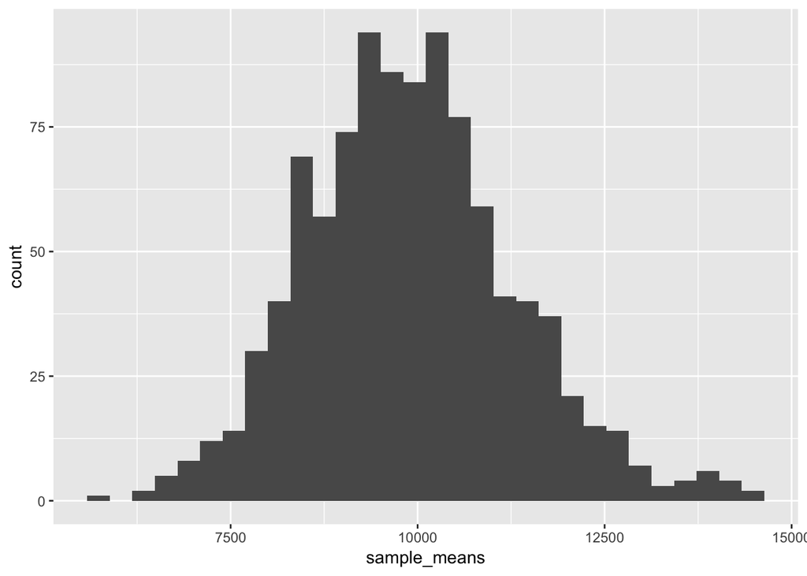

```r
step3data <- samp_fun(50, 1/10000)

sample_means_L <- step3data[1]
sample_sds_L <- step3data[2]

sample_means_df <- data.frame("sample_means" = step3data[1])
sample_sds_df <- data.frame("sample_sds" = step3data[2])

ggplot(data = sample_means_df, aes(x = sample_means)) +
  geom_histogram()
```

### Output the standard deviation of your sample means

```r
samp_mean_stdev <- sd(sample_means_df$sample_means)
samp_mean_stdev
```

```
## [1] 1393.536
```

# Exercise 2 - Linear Regression (5 points)

## Load the train.csv dataset into R and fit a regression model with:

y = SalePrice  
Features: LotArea, OverallQual, and ExterQual

```r
train <- read_csv("/Users/aherman/Downloads/train.csv")

train_reg <- lm(SalePrice ~ LotArea + OverallQual + ExterQual, data = train)
```

## Use the broom package to output the coefficients and the R-squared

```r
glance(train_reg)
```

```
## # A tibble: 1 x 11
##   r.squared adj.r.squared  sigma statistic p.value    df  logLik    AIC
##       <dbl>         <dbl>  <dbl>     <dbl>   <dbl> <int>   <dbl>  <dbl>
## 1     0.695         0.694 43948.      663.       0     6 -17677. 35368.
## # … with 3 more variables: BIC <dbl>, deviance <dbl>, df.residual <int>
```

```r
tidy(train_reg)
```

```
## # A tibble: 6 x 5
##   term         estimate std.error statistic   p.value
##   <chr>           <dbl>     <dbl>     <dbl>     <dbl>
## 1 (Intercept)  40764.   12358.         3.30 9.95e-  4
## 2 LotArea          1.45     0.116     12.5  3.72e- 34
## 3 OverallQual  34466.    1216.        28.3  4.77e-141
## 4 ExterQualFa -95352.   14592.        -6.53 8.80e- 11
## 5 ExterQualGd -71529.    6737.       -10.6  2.05e- 25
## 6 ExterQualTA -97527.    7541.       -12.9  2.72e- 36
```

## Interpret the coefficient on LotArea

LotArea is statistically significant. For every squre foot increase in Lot size, the average sale prie increaed by $1.45, assuming all else is equal.

## Interpret the coefficient on ExterQualGd

The mean difference in sale price for a Good exterior quality and an Excellent exterior quality is -71,529 dollars. In other words, with all else equal, going from an Excellent to a Good will result in a sales price decrease of 71,529 dollars.

## Compare this model to the model we fit in HW 7 with GrLivArea, OverallQual, Neighborhood. Which is the better fitting model?

The R-squared from the model in HW 7 is equal to .78. The R-squared in this model is .69, which indicates this model is less accurate.

# Exercise 3 - AB Testing (5 points)

We want to perform an AB test on this data to see if the conversion rates are different for the two versions of the webpage.

Answer these questions:

## What proportion of visitors converted for each version of the webpage?

```r
testdata <- read_csv("/Users/aherman/Downloads/ab_test_data.csv")

proportions <- testdata %>%
  group_by(version) %>%
  summarise(tot_conversions = sum(conversion), prop_conversion = mean(conversion))
proportions
```

```
## # A tibble: 2 x 3
##   version tot_conversions prop_conversion
##   <chr>             <dbl>           <dbl>
## 1 A                    83          0.0415
## 2 B                   200          0.1
```

4.15% of visitors converted for version A, while 10% of visitors converted for version B.

## Perform the AB test in R. What is the p-value for the AB test (hypothesis test of proportions)?

```r
true_a <- .0415
true_b <- .1
n_a <- 1000
n_b <- 1000

set.seed(10)
samp_a <- rbinom(n = 1, size = n_a, prob = true_a)
samp_b <- rbinom(n = 1, size = n_b, prob = true_b)

two_prop_test <- prop.test(c(samp_a, samp_b), c(1000, 1000))
two_prop_test$p.value
```

```
## [1] 1.467078e-08
```

The p-value is less than .05, therefore we know that the conversion rates between version A and B are significantly different.